# Analyzing Individual BGG Users

Phil Henrickson

2022-01-01

# **Tatuschrag’s** BoardGameGeek Collection

This notebook contains a set of analyses for the selected user’s boardgamegeek collection. The bulk of the analysis is focused on building a user-specific predictive model to predict the games that Tatuschrag is likely to own. This enables to ask questions like, based on the games the user currently owns, what games are a good fit for their collection? What upcoming games are they likely to purchase?

This analysis is based on data from BoardGameGeek that was last updated on **2021-12-20.**

# 1 Collection Overview

We can look at a basic description of the number of games that the user owns, has rated, has previously owned, etc.

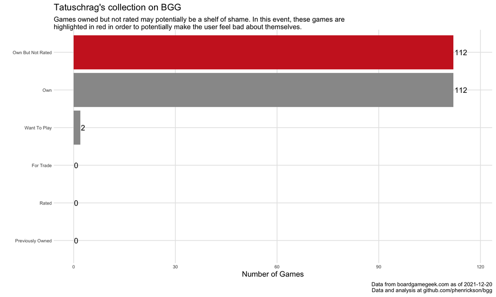

What years has the user owned/rated games from? While we can’t see when a user added or removed a game from their collection, we can look at their collection by the years in which their games were published.

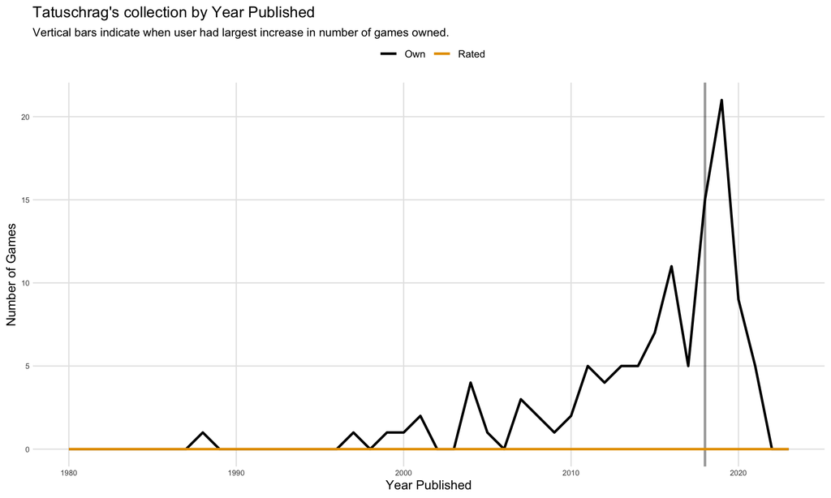

## 1.1 What types of games does Tatuschrag own?

We can look at the most frequent types of categories, mechanics, designers, and artists that appear in a user’s collection.

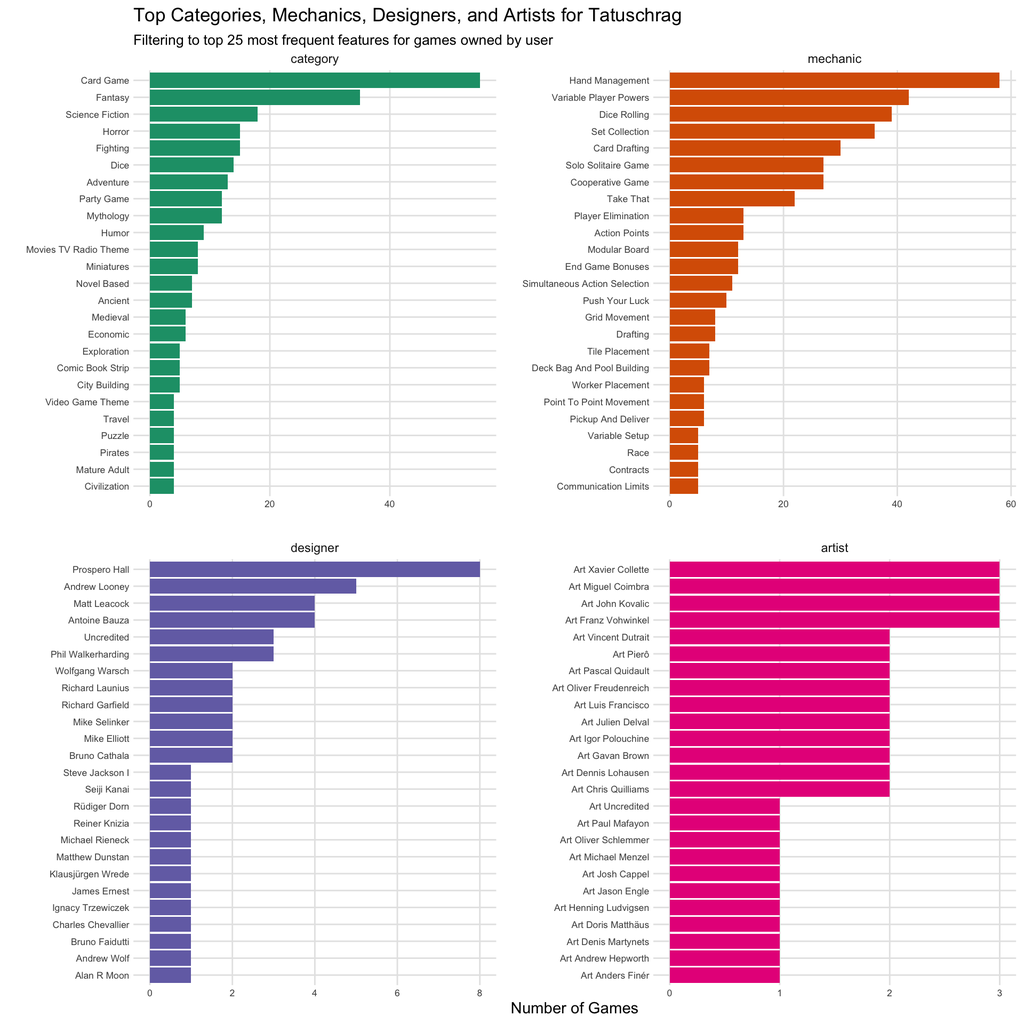

# 2 Modeling **Tatuschrag’s** Collection

| username | dataset | period | games_owned | games_rated | games_played |
| --- | --- | --- | --- | --- | --- |
| Tatuschrag | training | published before 2020 | 97 | 0 | 97 |
| Tatuschrag | test | published 2020 or later | 14 | 0 | 14 |

There are two main (binary) outcomes we will be modeling for the user.

The first, **own** refers to whether the user currently lists a game as owned in their collection. The second, **played** refers to whether the user currently owns, has rated, or previously owned a game. This means the latter will generally have a larger list of games, but may still be a useful category to examine for people who play lots of games without necessarily owning them.

We will train predictive models to learn the probability that the user will own or play individual games based on their features.

## 2.1 Coefficients for Tatuschrag

We can examine coefficients from the trained modes, which are penalized logistic regressions fit to our two main outcomes. Positive values indicate that a feature increases a user’s probabilility of owning/rating a game, while negative values indicate a feature decreases the probability.

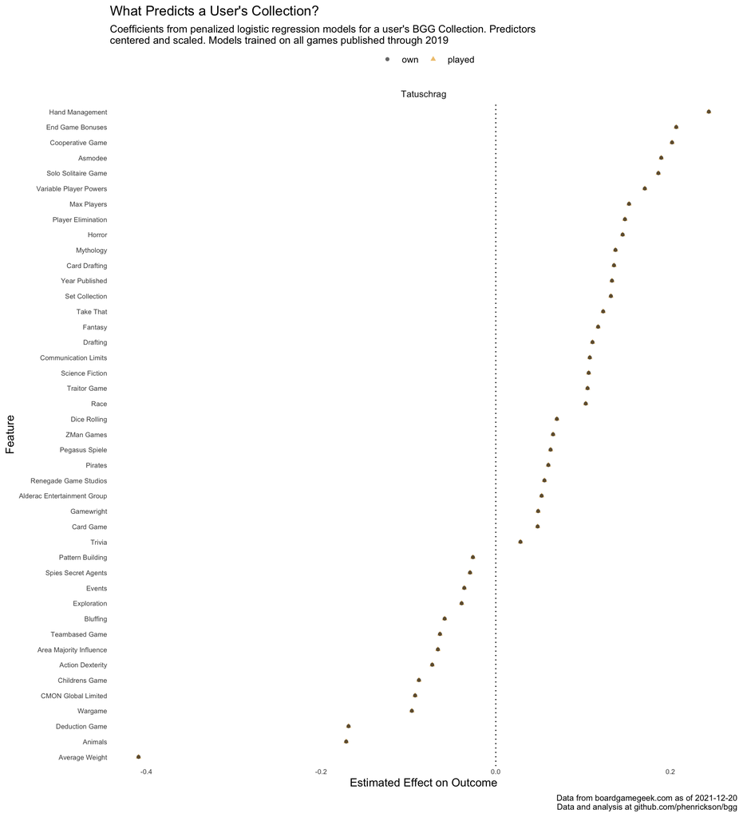

## 2.2 Visualizing Predictors for Tatuschrag’s Collection

Why did the model identify these features? We can make density plots of the important features for predicting whether the user owned a game. Blue indicates the density for games owned by the user, while grey indicates the density for games not owned by the user.

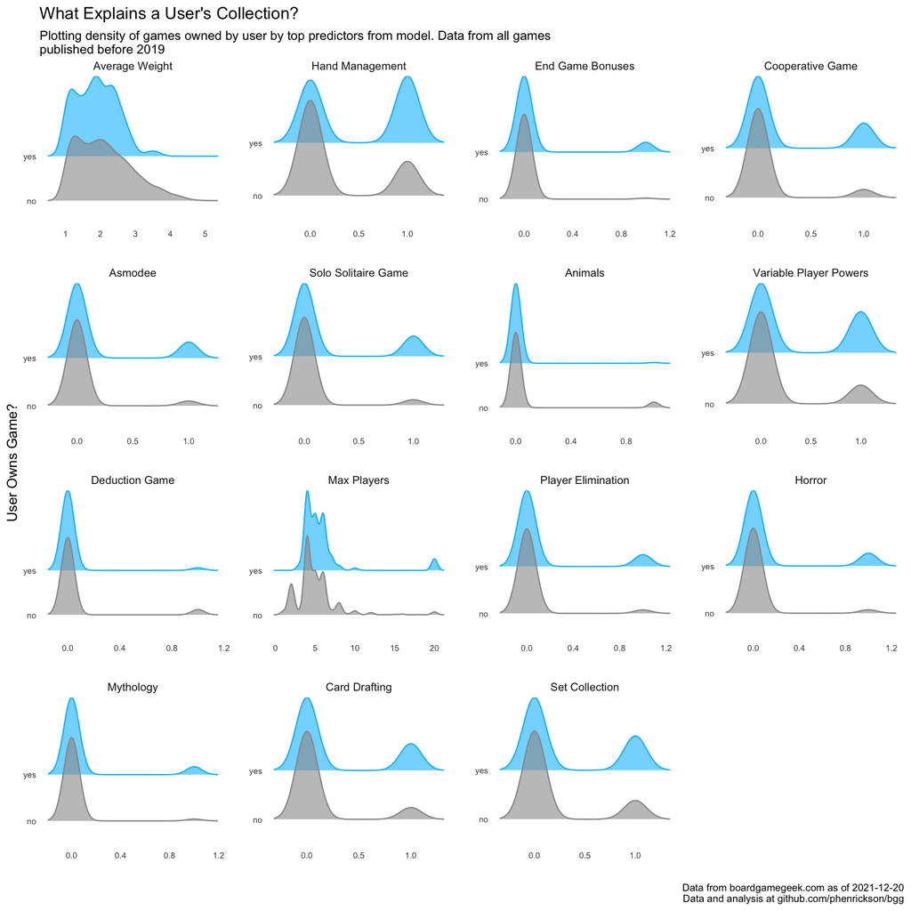

Binary predictors can be difficult to see with this visualization, so we can also directly examine the percentage of games in a user’s collection with a predictor vs the percentage of all games with that predictor.

| username | Feature | % of Games with Feature In_Collection | % of Games with Feature All_Games | Ratio |
| --- | --- | --- | --- | --- |
| Tatuschrag | End Game Bonuses | 11.3% | 1.2% | 9.7 |
| Tatuschrag | Drafting | 8.2% | 1.0% | 8.5 |
| Tatuschrag | Traitor Game | 4.1% | 0.6% | 6.4 |
| Tatuschrag | Communication Limits | 5.2% | 1.0% | 5.4 |
| Tatuschrag | Mythology | 9.3% | 2.2% | 4.3 |
| Tatuschrag | Solo Solitaire Game | 21.6% | 5.8% | 3.8 |
| Tatuschrag | Horror | 14.4% | 3.8% | 3.8 |
| Tatuschrag | Player Elimination | 13.4% | 3.9% | 3.4 |
| Tatuschrag | Asmodee | 17.5% | 5.3% | 3.3 |
| Tatuschrag | Cooperative Game | 25.8% | 8.4% | 3.1 |
| Tatuschrag | Take That | 18.6% | 6.5% | 2.8 |
| Tatuschrag | Race | 5.2% | 1.9% | 2.8 |
| Tatuschrag | Card Drafting | 26.8% | 11.8% | 2.3 |
| Tatuschrag | Variable Player Powers | 37.1% | 16.8% | 2.2 |
| Tatuschrag | Fantasy | 29.9% | 14.6% | 2.0 |
| Tatuschrag | Hand Management | 51.5% | 26.5% | 1.9 |
| Tatuschrag | Science Fiction | 16.5% | 8.7% | 1.9 |
| Tatuschrag | Set Collection | 32.0% | 17.5% | 1.8 |
| Tatuschrag | Dice Rolling | 36.1% | 28.8% | 1.3 |
| Tatuschrag | Deduction Game | 3.1% | 6.5% | 0.5 |
| Tatuschrag | Animals | 1.0% | 7.0% | 0.1 |
| Tatuschrag | Wargame | 0.0% | 12.6% | 0.0 |
| Tatuschrag | CMON Global Limited | 0.0% | 0.8% | 0.0 |
| Tatuschrag | Childrens Game | 0.0% | 5.7% | 0.0 |
| Tatuschrag | Action Dexterity | 0.0% | 4.9% | 0.0 |

# 3 Assess Model’s Performance on Training Set

Before predicting games in upcoming years, we can examine how well the model did and what games it liked in the training set. In this case, we used resampling techniques (cross validation) to ensure that the model had not seen a game before making its predictions.

## 3.1 Separation Plot

An easy way to examine the performance of classification model is to view a separation plot. We plot the predicted probabilities from the model for every game (from resampling) from lowest to highest. We then overlay a blue line for any game that the user does own. A good classifier is one that is able to *separate* the blue (games owned by the user) from the white (games not owned by the user), with most of the blue occurring at the highest probabilities (right side of the chart).

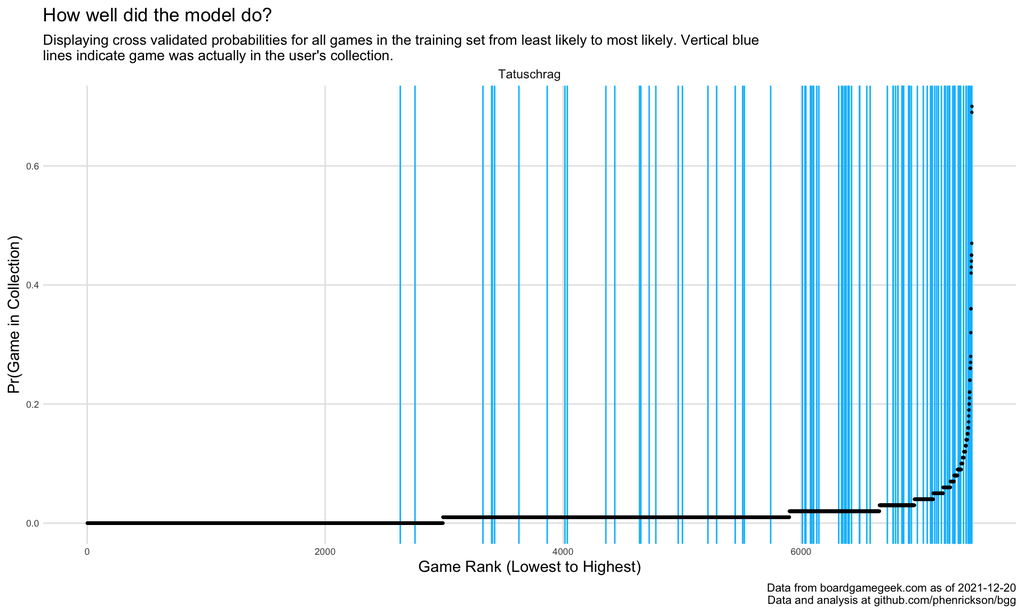

## 3.2 Top Games for **Tatuschrag** from Training Set

We can display this information in table form, displaying the 100 games with the highest probability of ownership, adding a blue line when the user does own the game.

| username | yearpublished | game_id | name | pred_played | pred_own | actual_played | actual_own |
| --- | --- | --- | --- | --- | --- | --- | --- |
| Tatuschrag | 2005 | 15062 | Shadows over Camelot | 0.70 | 0.70 | 0 | 0 |
| Tatuschrag | 2019 | 271324 | It's a Wonderful World | 0.69 | 0.69 | 1 | 1 |
| Tatuschrag | 2019 | 283863 | The Magnificent | 0.47 | 0.47 | 0 | 0 |
| Tatuschrag | 2019 | 270971 | Era: Medieval Age | 0.45 | 0.45 | 0 | 0 |
| Tatuschrag | 2016 | 167791 | Terraforming Mars | 0.45 | 0.45 | 0 | 0 |
| Tatuschrag | 2016 | 192291 | Sushi Go Party! | 0.44 | 0.44 | 0 | 0 |
| Tatuschrag | 2013 | 144325 | Munchkin Legends | 0.43 | 0.43 | 0 | 0 |
| Tatuschrag | 2019 | 260710 | Amul | 0.42 | 0.42 | 0 | 0 |
| Tatuschrag | 2018 | 258444 | Gingerbread House | 0.36 | 0.36 | 0 | 0 |
| Tatuschrag | 2015 | 171273 | FUSE | 0.36 | 0.36 | 0 | 0 |
| Tatuschrag | 2017 | 217861 | Paper Tales | 0.32 | 0.32 | 0 | 0 |
| Tatuschrag | 2013 | 133473 | Sushi Go! | 0.28 | 0.28 | 1 | 1 |
| Tatuschrag | 2019 | 266507 | Clank!: Legacy – Acquisitions Incorporated | 0.27 | 0.27 | 0 | 0 |
| Tatuschrag | 2014 | 154203 | Imperial Settlers | 0.26 | 0.26 | 0 | 0 |
| Tatuschrag | 2016 | 192153 | Pandemic: Reign of Cthulhu | 0.26 | 0.26 | 0 | 0 |
| Tatuschrag | 2016 | 205322 | The Oregon Trail Card Game | 0.26 | 0.26 | 1 | 1 |
| Tatuschrag | 2018 | 205896 | Rising Sun | 0.26 | 0.26 | 0 | 0 |
| Tatuschrag | 2014 | 151004 | Smash Up: Science Fiction Double Feature | 0.24 | 0.24 | 0 | 0 |
| Tatuschrag | 2016 | 176083 | Hit Z Road | 0.24 | 0.24 | 0 | 0 |
| Tatuschrag | 2014 | 144743 | Machina Arcana | 0.22 | 0.22 | 0 | 0 |
| Tatuschrag | 2019 | 264220 | Tainted Grail: The Fall of Avalon | 0.22 | 0.22 | 0 | 0 |
| Tatuschrag | 2013 | 127024 | Room 25 | 0.22 | 0.22 | 0 | 0 |
| Tatuschrag | 2019 | 266192 | Wingspan | 0.21 | 0.21 | 0 | 0 |
| Tatuschrag | 2013 | 52461 | Legacy: The Testament of Duke de Crecy | 0.20 | 0.20 | 0 | 0 |
| Tatuschrag | 2018 | 230253 | Star Realms: Frontiers | 0.20 | 0.20 | 0 | 0 |
| Tatuschrag | 2013 | 143185 | Smash Up: The Obligatory Cthulhu Set | 0.19 | 0.19 | 0 | 0 |
| Tatuschrag | 2015 | 180593 | The Bloody Inn | 0.19 | 0.19 | 1 | 1 |
| Tatuschrag | 2005 | 18258 | Mission: Red Planet | 0.18 | 0.18 | 0 | 0 |
| Tatuschrag | 2016 | 201808 | Clank!: A Deck-Building Adventure | 0.17 | 0.17 | 1 | 1 |
| Tatuschrag | 2016 | 177802 | Smash Up: It's Your Fault! | 0.16 | 0.16 | 0 | 0 |

[output cut: 70 more lines]

We can also more formally assess how well the model did in resampling by looking at the area under the receiver operating characteristic. A perfect model would receive a score of 1, while a model that cannot predict the outcome will default to a score of 0.5. The extent to which something is a *good* score depends on the setting, but generally anything in the .8 to .9 range is very good while the .7 to .8 range is perfectly acceptable.

| username | outcome_type | .metric | .estimator | .estimate |
| --- | --- | --- | --- | --- |
| Tatuschrag | own | roc_auc | binary | 0.847 |
| Tatuschrag | played | roc_auc | binary | 0.847 |

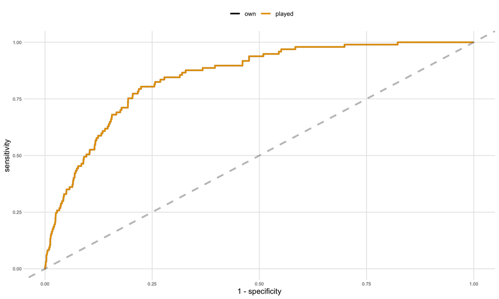

Another way to think about the model performance is to view its lift, or its ability to detect the positive outcomes over that of a null model. High lift indicates the model can much more quickly find all of the positive outcomes (in this case, games owned or played by the user), while a model with no lift is no better than random guessing.

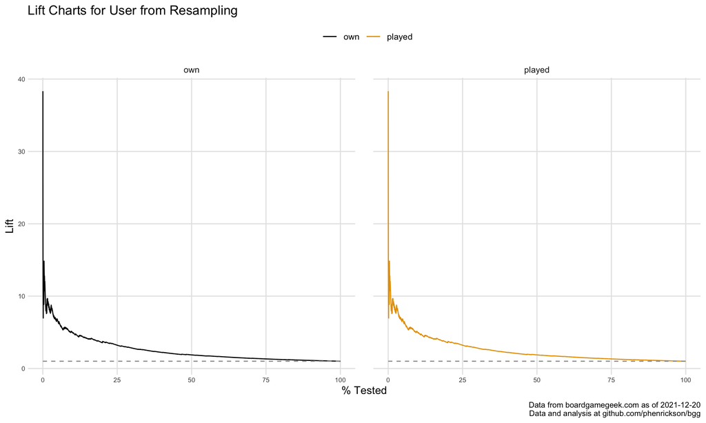

## 3.3 Most and Least Likely Games

What games does the model think Tatuschrag is **most likely to own** that are **not** in their collection?

| username | yearpublished | game_id | name | pred_own | actual_own |
| --- | --- | --- | --- | --- | --- |
| Tatuschrag | 2005 | 15062 | Shadows over Camelot | 0.70 | 0 |
| Tatuschrag | 2019 | 283863 | The Magnificent | 0.47 | 0 |
| Tatuschrag | 2019 | 270971 | Era: Medieval Age | 0.45 | 0 |
| Tatuschrag | 2016 | 167791 | Terraforming Mars | 0.45 | 0 |
| Tatuschrag | 2016 | 192291 | Sushi Go Party! | 0.44 | 0 |

What games does the model think Tatuschrag is **least likely to own** that **are** in their collection?

| username | yearpublished | game_id | name | pred_own | actual_own |
| --- | --- | --- | --- | --- | --- |
| Tatuschrag | 2016 | 170416 | Vast: The Crystal Caverns | 0.00 | 1 |
| Tatuschrag | 2000 | 822 | Carcassonne | 0.00 | 1 |
| Tatuschrag | 2013 | 141430 | Geek Out! | 0.01 | 1 |
| Tatuschrag | 2016 | 192458 | 51st State: Master Set | 0.01 | 1 |
| Tatuschrag | 2018 | 215341 | Thunderstone Quest | 0.01 | 1 |

## 3.4 Top Games by Year

Top 25 games most likely to be owned by the user in each year, highlighting in blue the games that the user has owned/played.

| rank | 2011 | 2012 | 2013 | 2014 | 2015 | 2016 | 2017 | 2018 | 2019 |
| --- | --- | --- | --- | --- | --- | --- | --- | --- | --- |
| 1 | Elder Sign | Il Vecchio | Munchkin Legends | Imperial Settlers | FUSE | Terraforming Mars | Paper Tales | Gingerbread House | It's a Wonderful World |
| 2 | Nightfall | Kairo | Sushi Go! | Smash Up: Science Fiction Double Feature | The Bloody Inn | Sushi Go Party! | Mountains of Madness | Rising Sun | The Magnificent |
| 3 | Mundus Novus | Smash Up | Room 25 | Machina Arcana | Exploding Kittens: NSFW Deck | Pandemic: Reign of Cthulhu | Bears vs Babies | Star Realms: Frontiers | Era: Medieval Age |
| 4 | Dungeon Raiders | Targi | Legacy: The Testament of Duke de Crecy | Five Tribes | Tiny Epic Galaxies | The Oregon Trail Card Game | XenoShyft: Dreadmire | Choose Your Own Adventure: House of Danger | Amul |
| 5 | Sentinels of the Multiverse | Zombicide | Smash Up: The Obligatory Cthulhu Set | Ultimate Werewolf: Deluxe Edition | The Game | Hit Z Road | Summit: The Board Game | The Order of Vampire Hunters | Clank!: Legacy – Acquisitions Incorporated |
| 6 | Ultimate Warriorz | Terra Mystica | Forbidden Desert | Pandemic: The Cure | Argonauts | Clank!: A Deck-Building Adventure | Exploding Kittens: Party Pack | Pandemic: Fall of Rome | Tainted Grail: The Fall of Avalon |
| 7 | Yggdrasil | Seasons | Zombicide Season 2: Prison Outbreak | Smash Up: Monster Smash | Valley of the Kings: Afterlife | Smash Up: It's Your Fault! | Spirit Island | Château Aventure | Wingspan |
| 8 | Flash Point: Fire Rescue | Urbion | Rory's Story Cubes: Prehistoria | Onirim (Second Edition) | Salem 1692 | Dead of Winter: The Long Night | Dungeon Time | Fantastic Beasts: Perilous Pursuit | Call to Adventure |
| 9 | Mage Knight Board Game | Love Letter | Pathfinder Adventure Card Game: Rise of the Runelords – Base Set | Valley of the Kings | Smash Up: Munchkin | Assembly | Ex Libris | Disney Villainous | Old West Empresario |
| 10 | Munchkin Axe Cop | Wits & Wagers Party | Lewis & Clark: The Expedition | Marrying Mr. Darcy | Grand Austria Hotel | Aeon's End | Arkham Noir: Case #1 – The Witch Cult Murders | Darkest Night (Second Edition) | Ragusa |
| 11 | Pergamemnon | Atlantis Rising | Smash Up: Awesome Level 9000 | Abyss | Unspeakable Words: Deluxe Edition | Islebound | Fate of the Elder Gods | Carthage | Minecraft: Builders & Biomes |
| 12 | Omen: A Reign of War | Libertalia | Eldritch Horror | Black Fleet | Zombicide Season 3: Rue Morgue | The Networks | Smash Up: What Were We Thinking? | Lords of Hellas | Arena: The Contest |
| 13 | Gears of War: The Board Game | Tokaido | Boss Monster: The Dungeon Building Card Game | Dragon's Hoard | Between Two Cities | Valley of the Kings: Last Rites | Mythic Battles: Pantheon | Newton | Similo |
| 14 | Takenoko | Rent a Hero | Munchkin Pathfinder | Legendary Encounters: An Alien Deck Building Game | The Pursuit of Happiness | Black Orchestra | Unstable Unicorns | Azul: Stained Glass of Sintra | Monster Baby Rescue! |
| 15 | Skull | Penny Arcade: The Game – Rumble in R'lyeh | Walk the Plank! | Colt Express | Kingdom Death: Monster | HMS Dolores | Gloomhaven | Sprawlopolis | Sierra West |
| 16 | Ascension: Return of the Fallen | Uncharted: The Board Game | The Hobbit: An Unexpected Journey | Ca$h 'n Guns (Second Edition) | Bang! The Dice Game: The Walking Dead | Citadels | Breaking Bad: The Board Game | Nemesis | Barrage |
| 17 | Martian Dice | Level 7 [Escape] | Ultimate Werewolf: Inquisition | Ultimate Werewolf | Exploding Kittens | Junk Art | The Dresden Files Cooperative Card Game | Boss Monster: Rise of the Minibosses | One Key |
| 18 | Ascension: Storm of Souls | Munchkin Apocalypse | Cardline: Globetrotter | Ancient Terrible Things | ...and then, we held hands. | Bloodborne: The Card Game | InBetween | Western Legends | Cartographers |
| 19 | Munchkin Zombies | Coup | Circus Train (Second Edition) | Splendor | Sylvion | Smash Up: Cease and Desist | Escape the Dark Castle | Arkham Noir: Case #2 – Called Forth By Thunder | Tiny Towns |
| 20 | The Walking Dead: The Board Game | The Manhattan Project | The Little Prince: Make Me a Planet | Warfighter: The Tactical Special Forces Card Game | Raptor | OrganATTACK! | Magic Maze | Heroes of Terrinoth | Yukon Airways |
| 21 | Cthulhu Gloom | Tzolk'in: The Mayan Calendar | The Doom That Came to Atlantic City | Belle of the Ball | Thunderbirds | Love Letter Premium | Century: Spice Road | Cahoots | Aquatica |
| 22 | Seven Dragons | Der Hobbit: Eine unerwartete Reise – Das Spiel zum Film | Dungeon Roll | Patchwork | Baseball Highlights: 2045 | Avenue | Century: Golem Edition | Who Goes There? | Last Bastion |
| 23 | 1911 Amundsen vs Scott | Hooyah: Navy Seals Card Game | Story War | Geek Out! Pop Culture Party | Heroes | Thief's Market | Bunny Kingdom | Pax Emancipation | Atlantis Rising (Second Edition) |
| 24 | Pantheon | Redshirts | Ghooost! | Castles of Mad King Ludwig | Love Letter: Batman | Pandemic: Iberia | Pandemic Legacy: Season 2 | Kero | The Crew: The Quest for Planet Nine |
| 25 | Rune Age | Diavolo | SOS Titanic | Run, Fight, or Die! | Munchkin Steampunk | Beyond Baker Street | Azul | Underwater Cities | Aerion |

## 3.5 Interactive Predictions from Resampling

Interactive table for predictions from resampling.

|  | username | yearpublished | rank | game_id | name | pred_played | pred_own | actual_played | actual_own |
| --- | --- | --- | --- | --- | --- | --- | --- | --- | --- |
| 1 | Tatuschrag | 1900 | 1280 | 45 | Perudo | 0.02 | 0.02 | 0 | 0 |
| 2 | Tatuschrag | 1900 | 1650 | 1602 | The Royal Game of Ur | 0.01 | 0.01 | 0 | 0 |
| 3 | Tatuschrag | 1900 | 1864 | 7316 | Bingo | 0.01 | 0.01 | 0 | 0 |
| 4 | Tatuschrag | 1900 | 2511 | 18121 | Casino | 0.01 | 0.01 | 0 | 0 |
| 5 | Tatuschrag | 1900 | 3220 | 15549 | Roulette | 0.01 | 0.01 | 0 | 0 |
| 6 | Tatuschrag | 1900 | 3358 | 15878 | Rummy | 0.01 | 0.01 | 0 | 0 |
| 7 | Tatuschrag | 1900 | 3572 | 15889 | Scopa | 0.01 | 0.01 | 0 | 0 |
| 8 | Tatuschrag | 1900 | 3769 | 11670 | The Game of Authors | 0.01 | 0.01 | 0 | 0 |
| 9 | Tatuschrag | 1900 | 3817 | 10799 | Old Maid | 0.01 | 0.01 | 0 | 0 |
| 10 | Tatuschrag | 1900 | 3838 | 1115 | Poker | 0.01 | 0.01 | 0 | 0 |

[output cut: 7426 more lines]

# 4 Validating the Model on 2020

How well did a model trained on a user’s collection through 2019 perform in predicting games for the user from 2020?

| username | outcome_type | yearpublished | .metric | .estimator | .estimate |
| --- | --- | --- | --- | --- | --- |
| Tatuschrag | own | 2020 | roc_auc | binary | 0.723 |
| Tatuschrag | played | 2020 | roc_auc | binary | 0.723 |

Table of top 25 games from 2020, highlighting games that the user owns.

| username | yearpublished | game_id | name | pred_own | pred_played | actual_own | actual_played |
| --- | --- | --- | --- | --- | --- | --- | --- |
| Tatuschrag | 2020 | 307844 | Atheneum: Mystic Library | 0.31 | 0.31 | 0 | 0 |
| Tatuschrag | 2020 | 304434 | Victim: The Cursed Forest | 0.29 | 0.29 | 0 | 0 |
| Tatuschrag | 2020 | 302310 | Nanaki | 0.27 | 0.27 | 0 | 0 |
| Tatuschrag | 2020 | 313698 | Monster Expedition | 0.22 | 0.22 | 0 | 0 |
| Tatuschrag | 2020 | 236861 | Full Moon Jacket | 0.17 | 0.17 | 0 | 0 |
| Tatuschrag | 2020 | 316377 | 7 Wonders (Second Edition) | 0.17 | 0.17 | 0 | 0 |
| Tatuschrag | 2020 | 291457 | Gloomhaven: Jaws of the Lion | 0.16 | 0.16 | 0 | 0 |
| Tatuschrag | 2020 | 276801 | Valhallamas | 0.15 | 0.15 | 0 | 0 |
| Tatuschrag | 2020 | 288513 | Tranquility | 0.13 | 0.13 | 0 | 0 |
| Tatuschrag | 2020 | 296151 | Viscounts of the West Kingdom | 0.13 | 0.13 | 0 | 0 |
| Tatuschrag | 2020 | 302840 | Carcata | 0.12 | 0.12 | 0 | 0 |
| Tatuschrag | 2020 | 184267 | On Mars | 0.11 | 0.11 | 0 | 0 |
| Tatuschrag | 2020 | 313850 | Escape The Night: The Board Game | 0.11 | 0.11 | 0 | 0 |
| Tatuschrag | 2020 | 295577 | Dungeon Mayhem: Monster Madness | 0.10 | 0.10 | 0 | 0 |
| Tatuschrag | 2020 | 298371 | Wild Space | 0.10 | 0.10 | 0 | 0 |
| Tatuschrag | 2020 | 262208 | Dungeon Drop | 0.09 | 0.09 | 0 | 0 |
| Tatuschrag | 2020 | 300081 | Hideous Abomination | 0.09 | 0.09 | 0 | 0 |
| Tatuschrag | 2020 | 304021 | Lost in Valhalla | 0.09 | 0.09 | 1 | 1 |
| Tatuschrag | 2020 | 320819 | Dinner in Paris | 0.09 | 0.09 | 0 | 0 |
| Tatuschrag | 2020 | 293556 | Gloomy Graves | 0.08 | 0.08 | 0 | 0 |
| Tatuschrag | 2020 | 301919 | Pandemic: Hot Zone – North America | 0.08 | 0.08 | 0 | 0 |
| Tatuschrag | 2020 | 316554 | Dune: Imperium | 0.08 | 0.08 | 0 | 0 |
| Tatuschrag | 2020 | 297204 | Traintopia | 0.07 | 0.07 | 0 | 0 |
| Tatuschrag | 2020 | 298352 | The Shining | 0.07 | 0.07 | 0 | 0 |
| Tatuschrag | 2020 | 302465 | Obsidia | 0.07 | 0.07 | 0 | 0 |

# 5 Predicting Upcoming Games (2020 and On) for **Tatuschrag**

Examine the top games for the test set.

| username | yearpublished | game_id | name | rank | own | played |
| --- | --- | --- | --- | --- | --- | --- |
| Tatuschrag | 2020 | 307844 | Atheneum: Mystic Library | 1 | 0.31 | 0.31 |
| Tatuschrag | 2020 | 304434 | Victim: The Cursed Forest | 2 | 0.29 | 0.29 |
| Tatuschrag | 2020 | 302310 | Nanaki | 3 | 0.27 | 0.27 |
| Tatuschrag | 2020 | 313698 | Monster Expedition | 4 | 0.22 | 0.22 |
| Tatuschrag | 2020 | 316377 | 7 Wonders (Second Edition) | 5 | 0.17 | 0.17 |
| Tatuschrag | 2020 | 236861 | Full Moon Jacket | 6 | 0.17 | 0.17 |
| Tatuschrag | 2020 | 291457 | Gloomhaven: Jaws of the Lion | 7 | 0.16 | 0.16 |
| Tatuschrag | 2020 | 276801 | Valhallamas | 8 | 0.15 | 0.15 |
| Tatuschrag | 2020 | 288513 | Tranquility | 9 | 0.13 | 0.13 |
| Tatuschrag | 2020 | 296151 | Viscounts of the West Kingdom | 10 | 0.13 | 0.13 |
| Tatuschrag | 2020 | 302840 | Carcata | 11 | 0.12 | 0.12 |
| Tatuschrag | 2020 | 184267 | On Mars | 12 | 0.11 | 0.11 |
| Tatuschrag | 2020 | 313850 | Escape The Night: The Board Game | 13 | 0.11 | 0.11 |
| Tatuschrag | 2020 | 298371 | Wild Space | 14 | 0.10 | 0.10 |
| Tatuschrag | 2020 | 295577 | Dungeon Mayhem: Monster Madness | 15 | 0.10 | 0.10 |
| Tatuschrag | 2020 | 262208 | Dungeon Drop | 16 | 0.09 | 0.09 |
| Tatuschrag | 2020 | 304021 | Lost in Valhalla | 17 | 0.09 | 0.09 |
| Tatuschrag | 2020 | 320819 | Dinner in Paris | 18 | 0.09 | 0.09 |
| Tatuschrag | 2020 | 300081 | Hideous Abomination | 19 | 0.09 | 0.09 |
| Tatuschrag | 2020 | 316554 | Dune: Imperium | 20 | 0.08 | 0.08 |
| Tatuschrag | 2020 | 301919 | Pandemic: Hot Zone – North America | 21 | 0.08 | 0.08 |
| Tatuschrag | 2020 | 293556 | Gloomy Graves | 22 | 0.08 | 0.08 |
| Tatuschrag | 2020 | 319604 | Ricochet: A la poursuite du Comte courant | 23 | 0.07 | 0.07 |
| Tatuschrag | 2020 | 302465 | Obsidia | 24 | 0.07 | 0.07 |
| Tatuschrag | 2020 | 298352 | The Shining | 25 | 0.07 | 0.07 |
| Tatuschrag | 2021 | 329465 | Red Rising | 1 | 0.44 | 0.44 |
| Tatuschrag | 2021 | 298102 | Roll Camera!: The Filmmaking Board Game | 2 | 0.43 | 0.43 |
| Tatuschrag | 2021 | 291859 | Riftforce | 3 | 0.23 | 0.23 |
| Tatuschrag | 2021 | 315624 | World Changers | 4 | 0.19 | 0.19 |
| Tatuschrag | 2021 | 310100 | Nemesis: Lockdown | 5 | 0.17 | 0.17 |
| Tatuschrag | 2021 | 309408 | Arcana Rising | 6 | 0.16 | 0.16 |
| Tatuschrag | 2021 | 319999 | Dungeon Decorators | 7 | 0.15 | 0.15 |
| Tatuschrag | 2021 | 282776 | Tumble Town | 8 | 0.14 | 0.14 |
| Tatuschrag | 2021 | 314589 | Night Parade of a Hundred Yokai | 9 | 0.14 | 0.14 |
| Tatuschrag | 2021 | 342848 | World of Warcraft: Wrath of the Lich King | 10 | 0.14 | 0.14 |
| Tatuschrag | 2021 | 335764 | Unmatched: Battle of Legends, Volume Two | 11 | 0.12 | 0.12 |
| Tatuschrag | 2021 | 331635 | Kameloot | 12 | 0.11 | 0.11 |
| Tatuschrag | 2021 | 267333 | Goetia: Nine Kings of Solomon | 13 | 0.11 | 0.11 |
| Tatuschrag | 2021 | 318474 | Who Goes There? 2nd Edition | 14 | 0.11 | 0.11 |
| Tatuschrag | 2021 | 314088 | Agropolis | 15 | 0.10 | 0.10 |
| Tatuschrag | 2021 | 325829 | Let's Summon Demons | 16 | 0.10 | 0.10 |
| Tatuschrag | 2021 | 319263 | One Card Dungeon | 17 | 0.10 | 0.10 |
| Tatuschrag | 2021 | 290236 | Canvas | 18 | 0.10 | 0.10 |
| Tatuschrag | 2021 | 280984 | Ruins: Death Binder | 19 | 0.09 | 0.09 |
| Tatuschrag | 2021 | 306182 | Bandada | 20 | 0.09 | 0.09 |
| Tatuschrag | 2021 | 318322 | Hidden Strike: American Revolution | 21 | 0.08 | 0.08 |
| Tatuschrag | 2021 | 318184 | Imperium: Classics | 22 | 0.08 | 0.08 |
| Tatuschrag | 2021 | 343562 | Horrified: American Monsters | 23 | 0.08 | 0.08 |
| Tatuschrag | 2021 | 333553 | For the King (and Me) | 24 | 0.08 | 0.08 |
| Tatuschrag | 2021 | 329593 | Settlement | 25 | 0.08 | 0.08 |
| Tatuschrag | 2022 | 317511 | Tindaya | 1 | 0.23 | 0.23 |
| Tatuschrag | 2022 | 331106 | The Witcher: Old World | 2 | 0.18 | 0.18 |
| Tatuschrag | 2022 | 295374 | Long Shot: The Dice Game | 3 | 0.16 | 0.16 |
| Tatuschrag | 2022 | 281258 | Sub Terra II: Inferno's Edge | 4 | 0.10 | 0.10 |
| Tatuschrag | 2022 | 273814 | Deliverance | 5 | 0.09 | 0.09 |
| Tatuschrag | 2022 | 295770 | Frosthaven | 6 | 0.08 | 0.08 |
| Tatuschrag | 2022 | 324090 | Scarface 1920 | 7 | 0.08 | 0.08 |
| Tatuschrag | 2022 | 334065 | Verdant | 8 | 0.06 | 0.06 |
| Tatuschrag | 2022 | 305096 | Endless Winter: Paleoamericans | 9 | 0.06 | 0.06 |
| Tatuschrag | 2022 | 284842 | So, You've Been Eaten | 10 | 0.06 | 0.06 |
| Tatuschrag | 2022 | 335427 | Wild: Serengeti | 11 | 0.06 | 0.06 |
| Tatuschrag | 2022 | 280726 | Legacies | 12 | 0.06 | 0.06 |
| Tatuschrag | 2022 | 304051 | Creature Comforts | 13 | 0.05 | 0.05 |
| Tatuschrag | 2022 | 336986 | Flamecraft | 14 | 0.04 | 0.04 |
| Tatuschrag | 2022 | 219650 | Arydia: The Paths We Dare Tread | 15 | 0.03 | 0.03 |
| Tatuschrag | 2022 | 277025 | Vampire: The Masquerade – CHAPTERS | 16 | 0.03 | 0.03 |
| Tatuschrag | 2022 | 275284 | Arkeis | 17 | 0.03 | 0.03 |
| Tatuschrag | 2022 | 274056 | HEL: The Last Saga | 18 | 0.03 | 0.03 |
| Tatuschrag | 2022 | 294529 | Entropia: The Game | 19 | 0.03 | 0.03 |
| Tatuschrag | 2022 | 326945 | Castles of Mad King Ludwig: Collector's Edition | 20 | 0.03 | 0.03 |
| Tatuschrag | 2022 | 286063 | The 7th Citadel | 21 | 0.03 | 0.03 |
| Tatuschrag | 2022 | 284118 | Mechanical Beast | 22 | 0.03 | 0.03 |
| Tatuschrag | 2022 | 303731 | Primal: The Awakening | 23 | 0.03 | 0.03 |
| Tatuschrag | 2022 | 322524 | Bardsung | 24 | 0.03 | 0.03 |
| Tatuschrag | 2022 | 283137 | Human Punishment: The Beginning | 25 | 0.02 | 0.02 |

## 5.1 Interactive Table for Upcoming Games 2020 and On

|  | username | yearpublished | game_id | name | rank | own | played |
| --- | --- | --- | --- | --- | --- | --- | --- |
| 1 | Tatuschrag | 2021 | 329465 | Red Rising | 1 | 0.44 | 0.44 |
| 2 | Tatuschrag | 2021 | 298102 | Roll Camera!: The Filmmaking Board Game | 2 | 0.43 | 0.43 |
| 3 | Tatuschrag | 2020 | 307844 | Atheneum: Mystic Library | 3 | 0.31 | 0.31 |
| 4 | Tatuschrag | 2020 | 304434 | Victim: The Cursed Forest | 4 | 0.29 | 0.29 |
| 5 | Tatuschrag | 2020 | 302310 | Nanaki | 5 | 0.27 | 0.27 |
| 6 | Tatuschrag | 2022 | 317511 | Tindaya | 6 | 0.23 | 0.23 |
| 7 | Tatuschrag | 2021 | 291859 | Riftforce | 7 | 0.23 | 0.23 |
| 8 | Tatuschrag | 2020 | 313698 | Monster Expedition | 8 | 0.22 | 0.22 |
| 9 | Tatuschrag | 2021 | 315624 | World Changers | 9 | 0.19 | 0.19 |
| 10 | Tatuschrag | 2022 | 331106 | The Witcher: Old World | 10 | 0.18 | 0.18 |

[output cut: 1627 more lines]